# Fractal dimension methods

```r
library(habtools)
library(raster)
```

fractal_intro.R

In this vignette, we give a brief overview of fractal dimension methods in `habtools`. There are currently five methods summarized in the table below. Each method has inherent biases and so should be used cautiously and consistently. For example, some methods are sensitive to particular elements, like outliers, axis-scaling or drop-offs, where others are invariant to them.

| Method | Function | Data | Default `lvec` | Notes |
| --- | --- | --- | --- | --- |
| Height variation | `hvar` | RasterLayer | 2-10 x resolution to extent | Invariant to height. Sensitive to non-fractal edges and outliers. |
| Standard deviation | `sd` | RasterLayer | 2-10 x resolution to extent | Invariant to height. Sensitive to non-fractal edges and outliers. |
| Area | `area` | RasterLayer or mesh3d | 2-4 x resolution to 1/8 extent | Sensitive to height; approaches 2 for surfaces with low height variation, relative to the extent. Less sensitive to non-fractal anomalies. |
| Cube counting | `cubes` | RasterLayer or mesh3d | 2-10 x resolution to extent | Sensitive to height; approaches 2 for for surfaces with low height variation, relative to the extent. More reliable for closed 3D object. Less sensitive to non-fractal anomalies. |
| Box counting | `boxes` | xy data.frame | 2-10 x resolution to extent | For 2D shapes only. Less sensitive to non-fractal anomalies. |

Generally, fractal dimension is estimated by measuring values (e.g., counts of cubes, heights, areas) across a sequence of different resolutions or length scales, and then finding the slope between these scales and measured values.

## The `lvec`

Selecting a sensible sequence of scales (i.e., the length vector `lvec`) is critical and should be the same when comparing surfaces and objects. The `lvec` should range between the resolution and extent of the surface or mesh, or across a range of scales relevant to the question being address. If you do not enter an `lvec`, each function will estimate one for you based on some rules of thumb for that particular method (see Table). For example, `hvar`, `sd`, `cubes` and `boxes` will generate a sequence from 2- to 10-times the resolution to the extent on a log2-scale. `area` will generate a sequence from 2 times the resolution to 1/8 the extent on the log2-scale.

The `area` method has increased bias with increased values inside `lvec`, because of the way surface area is calculated at each scale (using Jenness, 2004). The method calculates surface area of each cell by using the height of the cell and its 8 surrounding cells to create a surface. For border cells, the cells outside of the DEM are assumed to be of equal height as the border cells. This means that border cells may have lower surface area estimates. If the ratio of border cells to total cells inside a DEM is high, there may be an underestimation of surface area, which is the case when values inside `lvec` are too close to the extent. For example, if `lvec` contains a scale of extent/2, all the cells are border cells; if it contains extent/4, 75% of the cells are border cells. For this reason, the `area` method may be better suited for larger areas, relative to the `lvec`.

```
#> lvec is set to c(8, 16, 32, 64).
```

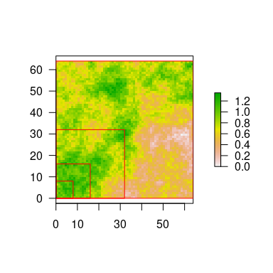

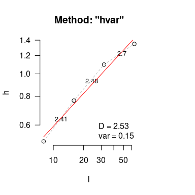

```
#> $D
#> [1] 2.526798
#>
#> $data
#>    l         h
#> 1  8 0.5096958
#> 2 16 0.7656256
#> 3 32 1.0974567
#> 4 64 1.3490052
#>
#> $lvec
#> [1]  8 16 32 64
#>
#> $D_vec
#> [1] 2.412997 2.480547 2.702268
#>
#> $var
#> [1] 0.1513279
#>
#> $method
#> [1] "hvar"
```

```r
# simulate fractal terrain
surf <- sim_dem(L = 64, smoothness = 0.5)

# fractal dimension using height variation method
fd(surf, method="hvar", plot = TRUE, diagnose = TRUE)
```

fractal_intro.R

When `plot=TRUE`, a plot of the surface is generated with red rectangles representing `lvec` to help visualize the scales at which fractal dimension is estimated. When `diagnostic=TRUE`, the relationship between scales and mean surface heights is plotted. The red line in the best-fit line for all point and dashed lines are for each pair-wise scale with localized D estimates. For the height range method, D is 3 minus the slope. The diagnostic plot helps identify scales that are problematic (typically the extremes of `lvec`), which then have bias the estimate. The `lvec` is returned and can then be altered, entered explicitly, and fractal dimension estimated again.

`hvar` and `sd` methods are not sensitive to z-axis scaling, whereas `area` and `cubes` methods are. Here are estimates for the relative flat surface we simulated with `smoothness=0.5`.

```r
# height variation
fd(surf, method = "hvar")
```

```
#> lvec is set to c(8, 16, 32, 64).
#> [1] 2.526798
```

```r
# standard deviation
fd(surf, method = "sd")
```

```
#> lvec is set to c(8, 16, 32, 64).
#> [1] 2.648066
```

```r
# area
fd(surf, method = "area")
```

```
#> lvec is set to c(2, 4, 8).
#> [1] 2.001568
```

```r
# cube counting
fd(surf, method = "cubes")
```

```
#> lvec is set to c(2, 4, 8, 16, 32, 64).
#> [1] 2
```

fractal_intro.R

```r
surf_z <- surf
values(surf_z) <- values(surf_z) * ((64-1) / hr(surf_z))
hr(surf_z)
```

```
#> [1] 63
```

```r
# height variation
fd(surf_z, method = "hvar")
```

```
#> lvec is set to c(8, 16, 32, 64).
#> [1] 2.526798
```

```r
# standard deviation
fd(surf_z, method = "sd")
```

```
#> lvec is set to c(8, 16, 32, 64).
#> [1] 2.648066
```

```r
# area
fd(surf_z, method = "area")
```

```
#> lvec is set to c(2, 4, 8).
#> [1] 2.542967
```

```r
# cube counting
fd(surf_z, method = "cubes")
```

```
#> lvec is set to c(2, 4, 8, 16, 32, 64).
#> [1] 2.35679
```

fractal_intro.R

`hvar` and `sd` estimates are identical (i.e., invariant to z-scaling) and `area` and `cubes` estimates are higher. This dichotomy raises an underlying philosophical question about fractal surfaces: does the fractal dimension of an surface change if it is transformed along a dimension?

The answer will likely depend on what you are analyzing. For example, if you are examining landscapes, then `area` and `cubes` methods will not be much use as they will tend to D=2 when surfaces a low relative to wide. Whereas, if you are examining surfaces that are as high as they are wide, then the `area` and `cubes` methods might be a better choice. If you are examining a closed 3D objects (i.e., watertight), then the `cubes` method is preferable as the 3D analogue to box counting on closed shapes like the coastline of the UK.

```
#> lvec is set to c(0.012, 0.024, 0.049, 0.097, 0.194, 0.389).
```

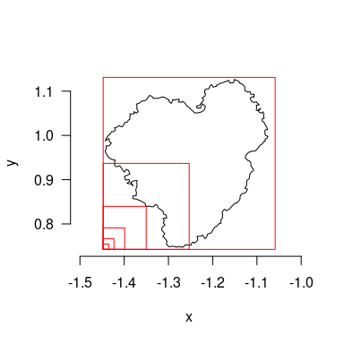

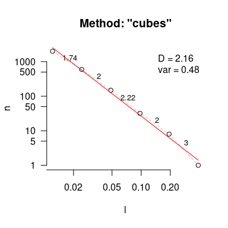

```
#> $D
#> [1] 2.162501
#>
#> $data
#>            l    n
#> 6 0.01214766 1995
#> 5 0.02429533  596
#> 4 0.04859066  149
#> 3 0.09718131   32
#> 2 0.19436262    8
#> 1 0.38872525    1
#>
#> $lvec
#> [1] 0.38872525 0.19436262 0.09718131 0.04859066 0.02429533 0.01214766
#>
#> $D_vec
#> [1] 1.743005 2.000000 2.219169 2.000000 3.000000
#>
#> $var
#> [1] 0.4819041
#>
#> $method
#> [1] "cubes"
```

```r
# cube counting
fd(mcap, method = "cubes", plot=TRUE, diagnose=TRUE)
```

fractal_intro.R

Here is an example of 2D box counting for the planar projection of the `mcap` mesh.

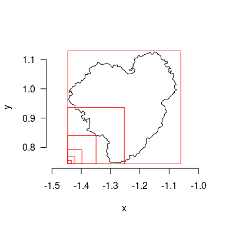

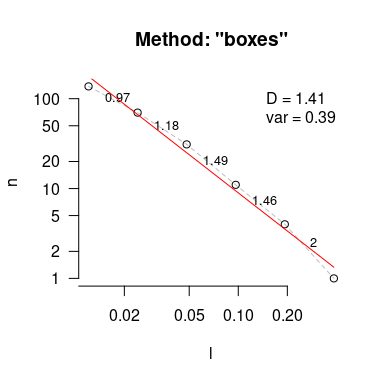

```
#> $D
#> [1] 1.410651
#>
#> $data
#>            l   n
#> 6 0.01205958 137
#> 5 0.02411915  70
#> 4 0.04823830  31
#> 3 0.09647661  11
#> 2 0.19295322   4
#> 1 0.38590644   1
#>
#> $lvec
#> [1] 0.38590644 0.19295322 0.09647661 0.04823830 0.02411915 0.01205958
#>
#> $D_vec
#> [1] 0.9687491 1.1750867 1.4947647 1.4594316 2.0000000
#>
#> $var
#> [1] 0.3896004
#>
#> $method
#> [1] "boxes"
```

```r
# project coral as xy coordinates
mcap_2d <- mesh_to_2d(mcap)

# box counting
fd(mcap_2d, method = "boxes", plot=TRUE, diagnose=TRUE)
```

fractal_intro.R

## Non-fractal surfaces

Natural surfaces often have anomalies such as peaks, troughs and edges that can result in biased fractal dimension estimates. It is up to the user to determine which method is best for their purposes, and to demonstrate that a biological or ecological result is robust to the choice of method. The function `detect_drop()` can help to investigate if a DEM has a lot of overhangs or sudden drops. It returns a raster where values mark the areas with sudden drops depending on a given threshold (Default threshold = 0.1).

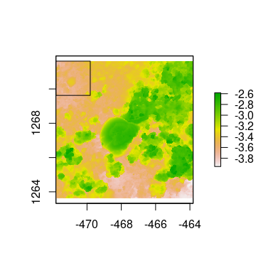

```r
dem1 <- dem_crop(horseshoe, x0 = -470.8104, y0 = 1270.625, L = 2, plot = TRUE)
```

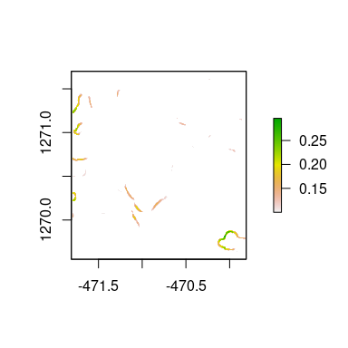

```r
drop1 <- detect_drop(dem1, d = 0.1)
plot(drop1)
```

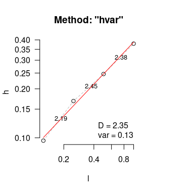

[output not shown]

[figure not shown]

```r
# This DEM does not have many drops
fd(dem1, method = "hvar", lvec = c(1, 0.5, 0.25, 0.125), diagnose=TRUE)
```

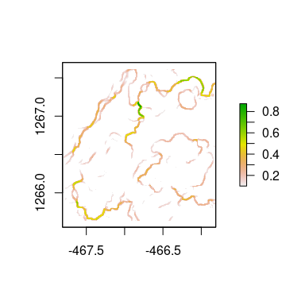

```r
drop2 <- detect_drop(dem2, d = 0.1)
plot(drop2)
```

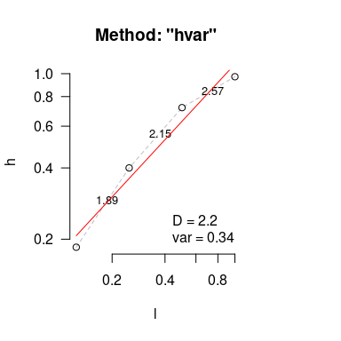

```
#> $D
#> [1] 2.198017
#>
#> $data
#>       l         h
#> 1 0.125 0.1849993
#> 2 0.250 0.3998837
#> 3 0.500 0.7186458
#> 4 1.000 0.9706139
#>
#> $lvec
#> [1] 0.125 0.250 0.500 1.000
#>
#> $D_vec
#> [1] 1.887939 2.154299 2.566383
#>
#> $var
#> [1] 0.3418205
#>
#> $method
#> [1] "hvar"
```

```r
fd(dem2, method = "hvar", lvec = c(1, 0.5, 0.25, 0.125), diagnose=TRUE)
```

fractal_intro.R

## References

- Jenness, J.S. Calculating Landscape Surface Area from Digital Elevation Models. Wildlife Society Bulletin, Vol. 32, No. 3 (Autumn, 2004), pp. 829-839.